# Keynote Speakers

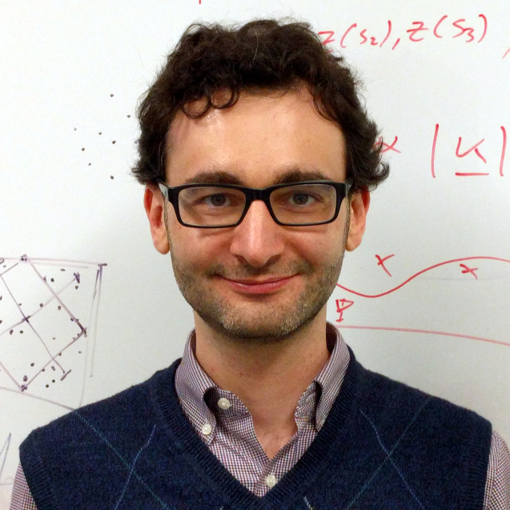

Prof. Pavel Krivitsky

Senior Lecturer in Statistics, University of New South Wales, Sydney, Australia

Prof. Krivitsky is a Senior Lecturer in Statistics at the University of New South Wales, Sydney. Previously, he served as a Lecturer in Statistics at the School of Mathematics and Applied Statistics and the National Institute for Applied Statistics Research Australia (NIASRA), a Research Associate at Pennsylvania State University, and a Visiting Research Associate at the Carnegie Mellon University Heinz College.

His research focuses on statistical modeling of social network data and processes, with applications in epidemiology, the social sciences, and defense. He is particularly interested in analyzing networks that are unusual, indirectly observed, or sampled in complex ways. With a strong emphasis on computation, Prof. Krivitsky develops and maintains several widely used R packages on CRAN, including **ergm**, **latentnet**, and **ergm.multi**.

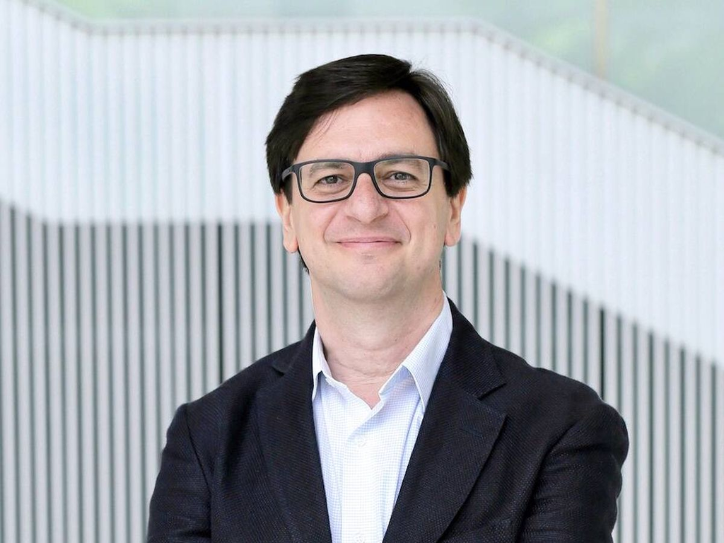

Prof. Esteban Moro

Professor, Network Science Institute, Northeastern University; Director, Social Urban Networks (SUNLab) Group

Prof. Moro is a Professor at the Network Science Institute at Northeastern University and Director of the Social Urban Networks (SUNLab) research group. Previously, he was an Associate Professor at Universidad Carlos III de Madrid (UC3M), a Researcher and Visiting Professor at the MIT Media Lab, and a Researcher at the University of Oxford.

A native of Salamanca, Spain, he holds a PhD in Physics and is also an Affiliate Researcher at the MIT Media Lab. Prof. Moro has published extensively, led numerous projects funded by government agencies and private companies, and served as a jury member for major Data Science and Big Data competitions. He has also been an editor for several journals and has supervised many PhD students.